# stage2draft

Mia

2025-10-05

# 1 Proposal Draft

```r
df <- read_csv("../datasets/cleaned_data.csv")
```

```r
df <- clean_names(df)
glimpse(df)
```

```
## Rows: 8,883
## Columns: 15
## $ neighborhood_overview          <dbl> 1, 1, 1, 0, 0, 0, 1, 1, 1, 1, 1, 1, 1, …
## $ host_acceptance_rate           <dbl> 99, 86, 92, 89, 55, 55, 70, 50, 93, 62,…
## $ neighbourhood_cleansed         <chr> "Sydney", "Sydney", "Mosman", "Hornsby"…
## $ latitude                       <dbl> -33.87964, -33.87888, -33.81748, -33.72…
## $ longitude                      <dbl> 151.2168, 151.2144, 151.2348, 151.0523,…
## $ room_type                      <chr> "Non-entire place", "Entire home/apt", …
## $ bathrooms                      <dbl> 1.0, 1.0, 1.0, 2.5, 1.0, 1.0, 1.0, 1.0,…
## $ bedrooms                       <dbl> 1, 1, 1, 2, 2, 2, 1, 2, 2, 2, 2, 1, 0, …
## $ beds                           <dbl> 1, 1, 3, 3, 2, 0, 2, 0, 2, 3, 3, 1, 1, …
## $ price                          <dbl> 99, 140, 179, 109, 218, 287, 127, 339, …
## $ maximum_nights                 <dbl> 90, 180, 90, 30, 300, 365, 90, 60, 730,…
## $ number_of_reviews              <dbl> 617, 82, 447, 120, 21, 2, 352, 18, 181,…
## $ calculated_host_listings_count <dbl> 1, 1, 1, 1, 5, 5, 2, 1, 2, 3, 7, 2, 3, …
## $ reviews_per_month              <dbl> 3.81, 0.46, 2.54, 0.70, 0.26, 0.27, 2.0…
## $ outcome                        <chr> "Third-month", "Indeterminate", "Third-…
```

```r
summary(df)
```

```
##  neighborhood_overview host_acceptance_rate neighbourhood_cleansed
##  Min.   :0.000         Min.   :  0.00       Length:8883
##  1st Qu.:0.000         1st Qu.: 88.00       Class :character
##  Median :1.000         Median : 98.00       Mode  :character
##  Mean   :0.533         Mean   : 88.94
##  3rd Qu.:1.000         3rd Qu.:100.00
##  Max.   :1.000         Max.   :100.00
##                        NA's   :506
##     latitude        longitude      room_type           bathrooms
##  Min.   :-34.10   Min.   :150.6   Length:8883        Min.   :0.500
##  1st Qu.:-33.90   1st Qu.:151.1   Class :character   1st Qu.:1.000
##  Median :-33.88   Median :151.2   Mode  :character   Median :1.000
##  Mean   :-33.85   Mean   :151.2                      Mean   :1.387
##  3rd Qu.:-33.82   3rd Qu.:151.3                      3rd Qu.:2.000
##  Max.   :-33.38   Max.   :151.3                      Max.   :7.000
##
##     bedrooms           beds            price       maximum_nights
##  Min.   : 0.000   Min.   : 0.000   Min.   : 28.0   Min.   :   2.0
##  1st Qu.: 1.000   1st Qu.: 1.000   1st Qu.:142.0   1st Qu.:  90.0
##  Median : 1.000   Median : 2.000   Median :203.0   Median : 365.0
##  Mean   : 1.725   Mean   : 2.194   Mean   :251.3   Mean   : 427.5
##  3rd Qu.: 2.000   3rd Qu.: 3.000   3rd Qu.:302.0   3rd Qu.: 365.0
##  Max.   :13.000   Max.   :16.000   Max.   :998.0   Max.   :1125.0
##  NA's   :4        NA's   :10
##  number_of_reviews calculated_host_listings_count reviews_per_month
##  Min.   :   1.00   Min.   :  1.00                 Min.   : 0.010
##  1st Qu.:   7.00   1st Qu.:  1.00                 1st Qu.: 0.540
##  Median :  24.00   Median :  3.00                 Median : 1.220
##  Mean   :  53.65   Mean   : 19.47                 Mean   : 1.629
##  3rd Qu.:  64.00   3rd Qu.: 19.00                 3rd Qu.: 2.250
##  Max.   :1227.00   Max.   :195.00                 Max.   :12.640
##
##    outcome
##  Length:8883
##  Class :character
##  Mode  :character
##
##
##
##
```

```r
skim(df)
```

Data summary

| Name | df |
| --- | --- |
| Number of rows | 8883 |
| Number of columns | 15 |
| _______________________ |  |
| Column type frequency: |  |
| character | 3 |
| numeric | 12 |
| ________________________ |  |
| Group variables | None |

**Variable type: character**

| skim_variable | n_missing | complete_rate | min | max | empty | n_unique | whitespace |
| --- | --- | --- | --- | --- | --- | --- | --- |
| neighbourhood_cleansed | 0 | 1 | 4 | 16 | 0 | 38 | 0 |
| room_type | 0 | 1 | 15 | 16 | 0 | 2 | 0 |
| outcome | 0 | 1 | 11 | 13 | 0 | 4 | 0 |

**Variable type: numeric**

| skim_variable | n_missing | complete_rate | mean | sd | p0 | p25 | p50 | p75 | p100 | hist |
| --- | --- | --- | --- | --- | --- | --- | --- | --- | --- | --- |
| neighborhood_overview | 0 | 1.00 | 0.53 | 0.50 | 0.00 | 0.00 | 1.00 | 1.00 | 1.00 | ▇▁▁▁▇ |
| host_acceptance_rate | 506 | 0.94 | 88.94 | 19.50 | 0.00 | 88.00 | 98.00 | 100.00 | 100.00 | ▁▁▁▁▇ |
| latitude | 0 | 1.00 | -33.85 | 0.09 | -34.10 | -33.90 | -33.88 | -33.82 | -33.38 | ▁▇▂▁▁ |
| longitude | 0 | 1.00 | 151.18 | 0.11 | 150.64 | 151.15 | 151.21 | 151.25 | 151.34 | ▁▁▁▅▇ |
| bathrooms | 0 | 1.00 | 1.39 | 0.63 | 0.50 | 1.00 | 1.00 | 2.00 | 7.00 | ▇▃▁▁▁ |
| bedrooms | 4 | 1.00 | 1.72 | 1.09 | 0.00 | 1.00 | 1.00 | 2.00 | 13.00 | ▇▂▁▁▁ |
| beds | 10 | 1.00 | 2.19 | 1.52 | 0.00 | 1.00 | 2.00 | 3.00 | 16.00 | ▇▂▁▁▁ |
| price | 0 | 1.00 | 251.30 | 169.64 | 28.00 | 142.00 | 203.00 | 302.00 | 998.00 | ▇▅▁▁▁ |
| maximum_nights | 0 | 1.00 | 427.46 | 386.74 | 2.00 | 90.00 | 365.00 | 365.00 | 1125.00 | ▆▇▁▁▃ |
| number_of_reviews | 0 | 1.00 | 53.65 | 81.16 | 1.00 | 7.00 | 24.00 | 64.00 | 1227.00 | ▇▁▁▁▁ |
| calculated_host_listings_count | 0 | 1.00 | 19.47 | 38.47 | 1.00 | 1.00 | 3.00 | 19.00 | 195.00 | ▇▁▁▁▁ |
| reviews_per_month | 0 | 1.00 | 1.63 | 1.49 | 0.01 | 0.54 | 1.22 | 2.25 | 12.64 | ▇▂▁▁▁ |

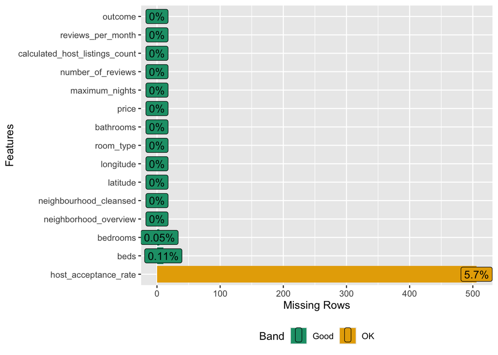

```r
df$outcome <- as.factor(df$outcome)
plot_missing(df)
```

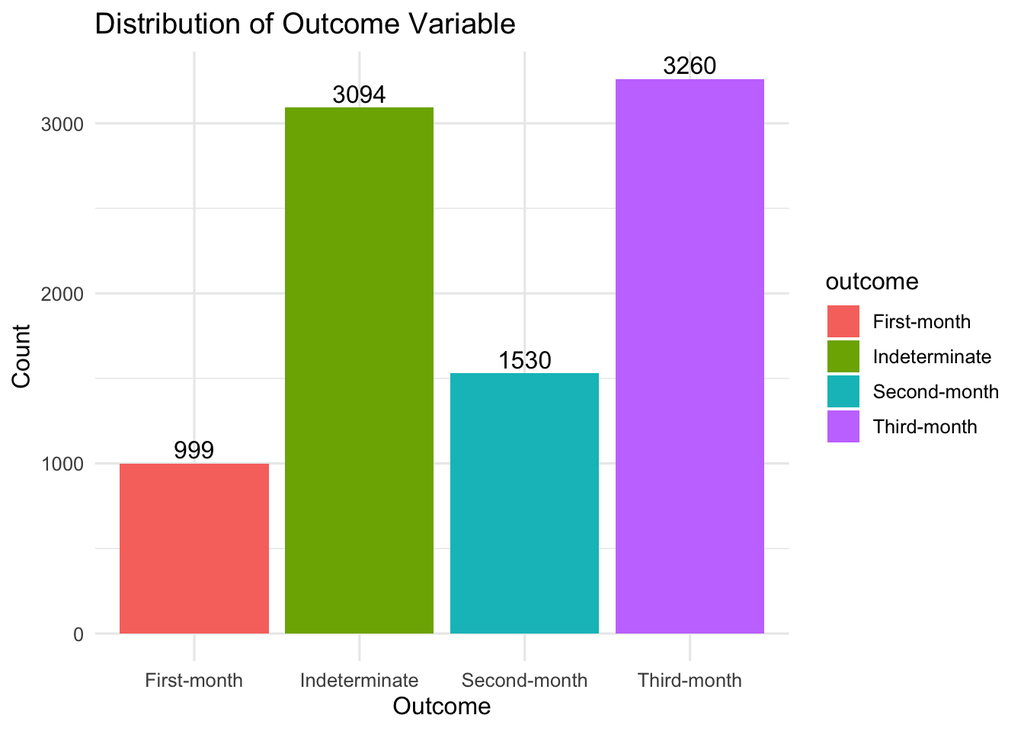

```r
ggplot(df, aes(x = outcome, fill = outcome)) +
  geom_bar() +
  geom_text(stat="count", aes(label=..count..), vjust=-0.3) +
  labs(title = "Distribution of Outcome Variable",
       y = "Count", x = "Outcome") +
  theme_minimal(base_size = 12)
```

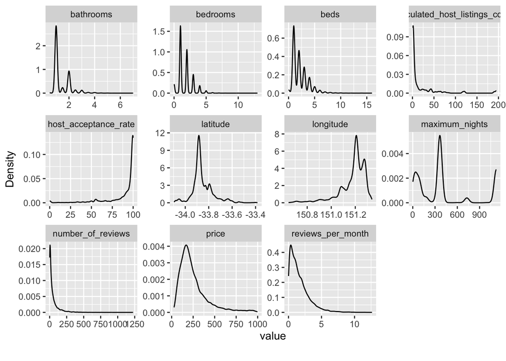

```r
num_vars <- df %>%
  select(where(is.numeric))

plot_density(num_vars)
```

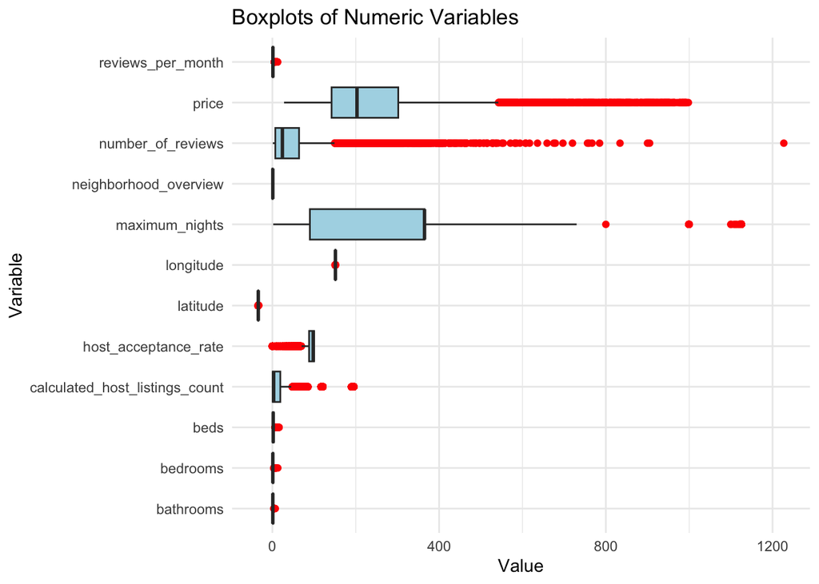

```r
num_vars_long <- num_vars %>%
  pivot_longer(cols = everything(), names_to = "variable", values_to = "value")

ggplot(num_vars_long, aes(x = variable, y = value)) +
  geom_boxplot(outlier.color = "red", fill = "lightblue") +
  coord_flip() +
  labs(title = "Boxplots of Numeric Variables",
       x = "Variable", y = "Value") +
  theme_minimal()
```

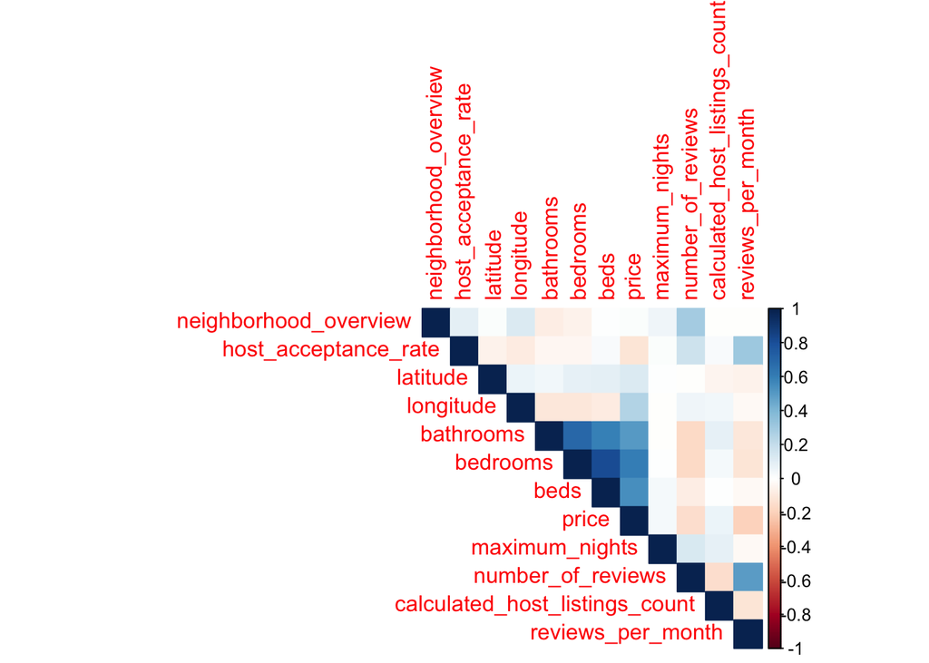

```r
cor_mat <- cor(num_vars, use = "pairwise.complete.obs")
corrplot::corrplot(cor_mat, type = "upper", method = "color")
```

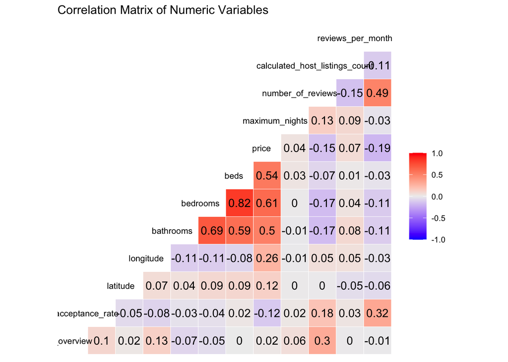

```r
num_df <- df %>%
  select(where(is.numeric))
GGally::ggcorr(num_df,
               label = TRUE, label_round = 2,
               hjust = 0.8, size = 3,
               low = "blue", high = "red") +
  labs(title = "Correlation Matrix of Numeric Variables") +
  theme_minimal(base_size = 10)
```

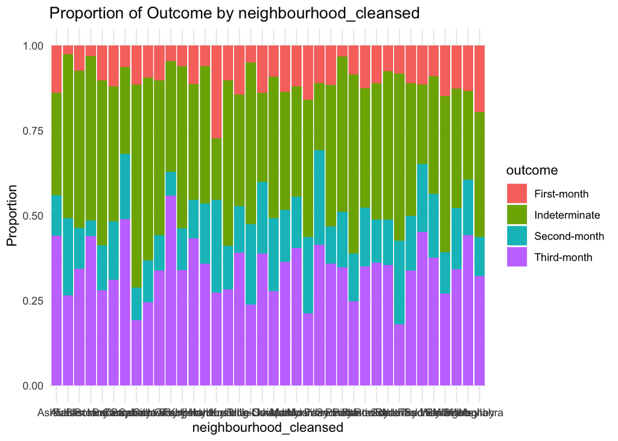

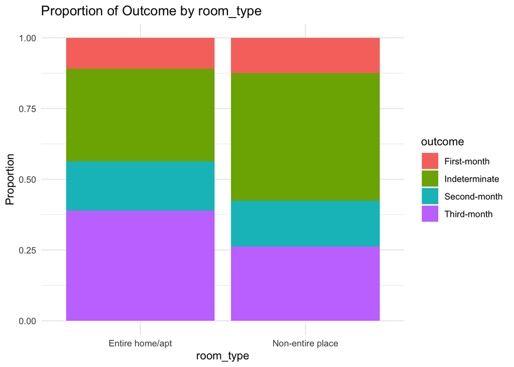

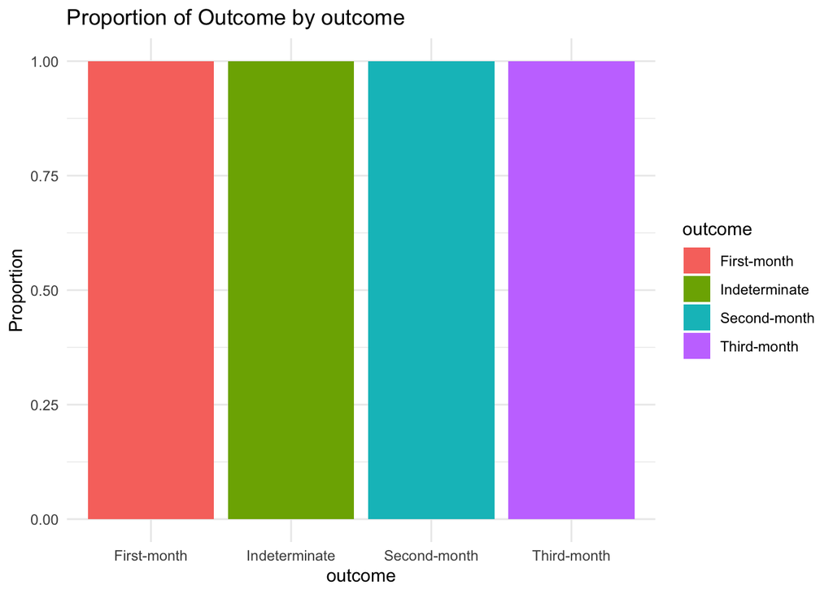

```r
cat_vars <- df %>%
  select(where(is.character) | where(is.factor))
for (v in head(names(cat_vars), 5)) {
  print(
    ggplot(df, aes_string(x = v, fill = "outcome")) +
      geom_bar(position = "fill") +
      labs(title = paste("Proportion of Outcome by", v),
           y = "Proportion") +
      theme_minimal()
  )
}
```

| 模型类型 | 模型名称 | 作用 | 备注 |  |
| --- | --- | --- | --- | --- |
| 线性基线 | Lasso Logistic Regression | 解释性强，验证线性可分性 | 用正则化控制共线性；先 log + scale |  |
| 非线性（弱模型） | Decision Tree | 可解释、快速 baseline | 作为简单树基线，对比复杂模型 |  |
| 非线性（集成主力） | Random Forest | 稳定强大、无需特征变换 可自然处理非线性与交互 |  |  |
| 非线性（提升型） | XGBoost | 性能最强，适合混合类型特征 | 调参略复杂，注意 class_weight |  |

*在报告部分，体现系统性和完整性：展示 3–5个模型的对比结果，通过表格和文字说明各模型的性能差异，并解释超参数选择与正则化逻辑，以体现分析的深度和科学性。报告中通常包含混淆矩阵、特征重要性图和总体性能表，用“系统性比较分析”的语气呈现。*

*Presentation阶段，重点在于清晰和故事性。聚焦于表现最好的一个模型，用简洁语言说明为什么它效果最好，讲模型背后的直觉和关键发现，而非技术细节。展示中可配合两到三个直观图表（如特征重要性图和混淆矩阵），让听众快速理解模型表现。整体语气更具叙事性，类似于“我们比较了多种模型，最终发现x表现最稳定、最准确”。*

Macro-F1 是各类别 F1-score 的算术平均，用于衡量模型在不平衡多分类任务中的总体表现：

$$F1_i = \frac{2 \times \text{Precision}_i \times \text{Recall}_i}
{\text{Precision}_i + \text{Recall}_i}$$

$$\text{Macro-F1} = \frac{1}{K} \sum_{i=1}^{K} F1_i$$
其中 $K$ 为类别总数。

Accuracy 衡量模型预测正确的样本比例：

$$\text{Accuracy} = \frac{TP + TN}{TP + TN + FP + FN}$$
对于多分类任务，可写为：
$$\text{Accuracy} = \frac{\sum_{i=1}^{K} TP_i}{N}$$
其中 $TP_i$ 表示第 $i$ 类被正确预测的样本数，$N$ 为总样本数。

在多分类任务中，Macro ROC-AUC 通过 One-vs-Rest（OvR）方式计算：
$$\text{AUC}_i = \int_0^1 TPR_i(FPR_i^{-1}(x)) \, dx$$

$$\text{Macro ROC-AUC} = \frac{1}{K} \sum_{i=1}^{K} \text{AUC}_i$$
其中： - $TPR_i = \frac{TP_i}{TP_i + FN_i}$ 为真正率； - $FPR_i = \frac{FP_i}{FP_i + TN_i}$ 为假正率。

# 2 Model Draft

```r
library(tidymodels)
library(themis)
library(yardstick)
library(kableExtra)
library(doParallel)
cores <- detectCores() - 1
registerDoParallel(cores = cores)
```

```r
set.seed(5003)
df$outcome <- as.factor(df$outcome)

split <- initial_split(df, prop = 0.8, strata = outcome)
train <- training(split); test <- testing(split)
folds <- vfold_cv(train, v = 10, strata = outcome)

rec <- recipe(outcome ~ ., data = train) |>
  step_string2factor(all_nominal_predictors()) |>
  step_other(neighbourhood_cleansed, threshold = 0.02) |>
  step_dummy(all_nominal_predictors(), one_hot = TRUE) |>
  step_impute_median(all_numeric_predictors()) |>
  step_log(price, number_of_reviews, reviews_per_month,
           offset = 1, skip = TRUE) |>
  step_normalize(all_numeric_predictors())

metric_set_all <- metric_set(accuracy, f_meas, roc_auc)
```

```r
# Lasso Logistic
mod_lasso <- multinom_reg(penalty = tune(), mixture = 1) |>
  set_engine("glmnet") |> set_mode("classification")

# Decision Tree
mod_tree <- decision_tree(tree_depth = tune(), cost_complexity = tune()) |>
  set_engine("rpart") |> set_mode("classification")

# Random Forest
mod_rf <- rand_forest(mtry = tune(), trees = 300, min_n = tune()) |>
  set_engine("ranger", importance = "impurity") |> set_mode("classification")

# XGBoost
mod_xgb <- boost_tree(trees = 300, learn_rate = tune(), tree_depth = tune(),
                      loss_reduction = tune(), min_n = tune()) |>
  set_engine("xgboost", eval_metric = "mlogloss") |> set_mode("classification")
```

```r
wf_lasso <- workflow() |> add_model(mod_lasso) |> add_recipe(rec)
wf_tree  <- workflow() |> add_model(mod_tree)  |> add_recipe(rec)
wf_rf    <- workflow() |> add_model(mod_rf)    |> add_recipe(rec)
wf_xgb   <- workflow() |> add_model(mod_xgb)   |> add_recipe(rec)
grid_lasso <- grid_regular(penalty(range = c(-5, 0)), levels = 3)
grid_tree  <- grid_regular(tree_depth(), cost_complexity(), levels = 3)
grid_rf    <- grid_regular(mtry(range = c(3L, 10L)), min_n(), levels = 3)

grid_xgb <- grid_random(
  learn_rate(range = c(0.05, 0.3)),
  tree_depth(range = c(3L, 8L)),
  loss_reduction(range = c(0, 1)),
  min_n(range = c(2L, 8L)),
  size = 5
)
```

```r
library(ranger)
library(xgboost)
# Lasso
res_lasso <- tune_grid(wf_lasso, resamples = folds, grid = grid_lasso, metrics = metric_set_all)
best_lasso <- select_best(res_lasso, metric = "f_meas")
final_lasso <- finalize_workflow(wf_lasso, best_lasso) |> fit(train)

# Decision Tree
res_tree <- tune_grid(wf_tree, resamples = folds, grid = grid_tree, metrics = metric_set_all)
best_tree <- select_best(res_tree, metric = "f_meas")
final_tree <- finalize_workflow(wf_tree, best_tree) |> fit(train)

# Random Forest
res_rf <- tune_grid(wf_rf, resamples = folds, grid = grid_rf, metrics = metric_set_all)
best_rf <- select_best(res_rf, metric = "f_meas")
final_rf <- finalize_workflow(wf_rf, best_rf) |> fit(train)

# XGBoost
res_xgb <- tune_grid(wf_xgb, resamples = folds, grid = grid_xgb, metrics = metric_set_all)
best_xgb <- select_best(res_xgb, metric = "f_meas")
final_xgb <- finalize_workflow(wf_xgb, best_xgb) |> fit(train)
```

```r
eval_metrics <- function(model_fit, test_data) {
  test_data$outcome <- factor(test_data$outcome,
                              levels = levels(train$outcome))

  pred <- predict(model_fit, test_data, type = "prob") |>
    bind_cols(predict(model_fit, test_data)) |>
    bind_cols(test_data |> select(outcome))

  acc <- accuracy(pred, truth = outcome, estimate = .pred_class) |> pull(.estimate)
  f1  <- f_meas(pred, truth = outcome, estimate = .pred_class, estimator = "macro") |> pull(.estimate)

  auc <- tryCatch({
    roc_auc(pred, truth = outcome,
            dplyr::matches("^\\.pred_(?!class)", perl = TRUE),
            estimator = "hand_till") |>
      dplyr::pull(.estimate) |>
      as.numeric()
  }, error = function(e) NA_real_)

  tibble(Accuracy = acc, Macro_F1 = f1, Macro_ROC_AUC = auc)
}
```

```r
test$outcome <- factor(test$outcome, levels = levels(train$outcome))

results <- bind_rows(
  eval_metrics(final_lasso, test) |> mutate(Model = "Lasso Logistic Regression"),
  eval_metrics(final_tree,  test) |> mutate(Model = "Decision Tree"),
  eval_metrics(final_rf,    test) |> mutate(Model = "Random Forest"),
  eval_metrics(final_xgb,   test) |> mutate(Model = "XGBoost")
) |> select(Model, Accuracy, Macro_F1, Macro_ROC_AUC)

kable(results,
      digits = 3, align = "c") |>
  kable_styling(full_width = FALSE, position = "center",
                bootstrap_options = c("hover", "condensed"))
```

| Model | Accuracy | Macro_F1 | Macro_ROC_AUC |
| --- | --- | --- | --- |
| Lasso Logistic Regression | 0.367 | 0.537 | 0.500 |
| Decision Tree | 0.456 | 0.526 | 0.557 |
| Random Forest | 0.467 | 0.272 | 0.629 |
| XGBoost | 0.352 | 0.298 | 0.571 |

模型虽能捕捉到一定的判别信号，但整体预测能力有限，表现远低于常规可预测任务（通常 Accuracy > 0.8）

尽管 outcome 来源于原始数据的可用天数 (availability_30, availability_60, availability_90)，但其实质是对“相对月度空房趋势”的分类编码。 由于多数房源在三个月内的可用天数差异极小（往往仅相差数日），标签本身存在较强的模糊性与噪声。

四类 outcome 在特征空间中的分布高度重叠；

特征如 price、beds、bathrooms 等在各类之间无明显分区；

说明特征对 outcome 的可分性较弱（weak separability）。

因此，即便模型架构复杂、非线性（如 XGBoost），其性能提升也受限于输入特征的信息量，而非模型表达力。

这些结果表明模型并非完全失效，而是受限于标签定义与特征解释力。 AUC 大于 0.6 已说明模型能部分识别某些类别的特征模式，但分类边界模糊。

- 标签噪声（Label noise）：outcome 基于数值差异极小的三个连续变量推导，许多样本近似随机分配至不同类别。
- 特征缺乏判别力（Low feature discrimination）：现有特征主要描述 listing 的结构与定价，对未来月度出租变化的预测性有限。
- 类别不平衡（Class imbalance）：“Indeterminate” 类占比较高，导致模型倾向预测该类，压低 Macro-F1。
- 任务定义问题（Task framing）：预测“哪个月最空”属于高噪声任务，本质上更接近模式探索（exploratory modelling）而非 deployable prediction。

改进方向

- 标签优化：去除 “Indeterminate” 类样本，减少模糊边界。
- 特征工程：引入差值与波动特征，如 `delta_1m = availability_60 - availability_30`，`var_3m = var(c(avail_30, avail_60, avail_90))`
- 采样平衡：在建模前应用 up/down-sampling 平衡类别。

```r
orig = read_csv("../datasets/listings.csv")

set.seed(5003)

#Step0 Drop the irrelevant columns

#Drop the columns which are irrelevant for prediction, sensitive, redundant, or unusable.
DROP <- c("scrape_id","host_name", "host_about", "host_thumbnail_url", "host_picture_url", "host_id","id", "listing_url", "name", "description", "picture_url", "host_url", "host_neighbourhood", "availability_eoy", "number_of_reviews_ly", "estimated_occupancy_l365d", "estimated_revenue_l365d", "source", "host_response_time", "host_response_rate", "host_is_superhost", "host_verifications", "host_has_profile_pic", "host_identity_verified","neighbourhood", "amenities","calendar_updated", "calendar_last_scraped","review_scores_rating", "review_scores_accuracy","review_scores_cleanliness", "review_scores_checkin","review_scores_communication", "accommodates",  "review_scores_location","review_scores_value","property_type", "calendar_updated", "minimum_minimum_nights", "maximum_minimum_nights", "minimum_maximum_nights", "maximum_maximum_nights", "minimum_nights_avg_ntm", "maximum_nights_avg_ntm","neighbourhood_group_cleansed", "host_listings_count", "calculated_host_listings_count_entire_homes", "calculated_host_listings_count_private_rooms", "calculated_host_listings_count_shared_rooms", "last_review", "host_tenure", "listing_age" , "bathrooms_text", "host_location","host_since", "first_review","number_of_reviews_ltm" ,"number_of_reviews_l30d", "last_scraped","license","has_availability", "availability_365", "minimum_nights", "host_total_listings_count", "instant_bookable", "month1","month2","month3")

step1 <- orig %>%

# step1 Clean and engineer multiple features

  # Fill bathrooms from bathrooms_text if missing; "half"=0.5 else extract number
  mutate(bathrooms = coalesce(bathrooms,case_when(str_detect(bathrooms_text, regex("half", ignore_case = TRUE)) ~ 0.5,TRUE ~ as.numeric(str_extract(bathrooms_text, "\\d+(?:\\.\\d+)?")))),

    # Parse dates to Date objects
    host_since = ymd(host_since),
    first_review = ymd(first_review),
    last_scraped = ymd(last_scraped),

    # Calculate host tenure and listing age in days
    host_tenure = as.numeric(last_scraped - host_since, units = "days"),
    listing_age = as.numeric(last_scraped - first_review, units = "days"),

    # Neighborhood overview: 1 if non-empty, else 0
    neighborhood_overview = ifelse(!is.na(neighborhood_overview) & neighborhood_overview != "", 1, 0),
    host_acceptance_rate = as.numeric(str_remove(host_acceptance_rate, "%")),

    # Remove "%", "$" and convert to numeric
    price = as.numeric(str_remove(price, "[$]")))


# step 2 sanity check and filtering stage
step2 <- step1 %>%
  filter(across(.cols = where(is.numeric) & !c("longitude", "latitude"), .fns  = ~ is.na(.x) | .x >= 0),# Keep only non-negative numeric values (except lat/long)
    price > 0,                               # Require positive price
    host_tenure >= listing_age,              # Ensure host tenure >= listing age
    str_detect(host_location, "Australia"),  # Host must be located in Australia
    license != "",                           # License field must not be empty
    price != "",                             # Price field must not be blank
    has_availability != "",                  # Availability field must not be blank
    bathrooms != 0)

# step 3
cleaned <- step2 %>%
  # Create monthly availability windows
  mutate(
    month1 = availability_30,                        # Availability in the first 30 days
    month2 = availability_60 - availability_30,      # Availability in days 31–60
    month3 = availability_90 - availability_60) %>%       # Availability in days 61–90
  rowwise() %>%
  # Define outcome category based on the month with maximum availability
  mutate(
    outcome = {
      vals <- c(month1, month2, month3)              # Collect availability values
      max_val <- max(vals, na.rm = TRUE)             # Find maximum availability
      if (sum(vals == max_val, na.rm = TRUE) > 1) {  # If tie across months
        "Indeterminate"                              # → Assign as Indeterminate
      } else {
        which_max <- which.max(vals)                 # Otherwise, get index of max
        c("First-month", "Second-month", "Third-month")[which_max]}}) %>%  # Map to category
  ungroup() %>%  # Return to ungrouped data frame

# step 4
  select(-any_of(DROP)) # Drop all columns listed in DROP
```

```r
set.seed(5003)
df2 <- cleaned |>
  filter(outcome != "Indeterminate") |>
  mutate(outcome = factor(outcome),
    delta_1m = availability_60 - availability_30,
    delta_2m = availability_90 - availability_60,
    var_3m   = apply(
      cbind(availability_30, availability_60, availability_90), 1, var))
```

```r
set.seed(5003)
split2 <- initial_split(df2, prop = 0.8, strata = outcome)
train2 <- training(split2)
test2  <- testing(split2)
folds2 <- vfold_cv(train2, v = 10, strata = outcome)

rec2 <- recipe(outcome ~ ., data = train2) |>
  step_string2factor(all_nominal_predictors()) |>
  step_other(neighbourhood_cleansed, threshold = 0.01) |>
  step_dummy(all_nominal_predictors(), one_hot = TRUE) |>
  step_log(price, number_of_reviews, reviews_per_month, offset = 1) |>
  step_normalize(all_numeric_predictors()) |>
  step_upsample(outcome)
```

```r
wf_rf2 <- workflow() |> add_model(mod_rf) |> add_recipe(rec2)
res_rf2 <- tune_grid(
  wf_rf2, resamples = folds2, grid = grid_rf,
  metrics = metric_set(accuracy, f_meas, roc_auc)
)
best_rf2 <- select_best(res_rf2, metric = "f_meas")
final_rf2 <- finalize_workflow(wf_rf2, best_rf2) |> fit(train2)
```

```r
pred_rf2 <- predict(final_rf2, test2, type = "prob") |>
  bind_cols(predict(final_rf2, test2)) |>
  bind_cols(test2 |> select(outcome))

acc <- accuracy(pred_rf2, truth = outcome, estimate = .pred_class)$.estimate
f1  <- f_meas(pred_rf2, truth = outcome, estimate = .pred_class, estimator = "macro")$.estimate
auc <- roc_auc(pred_rf2, truth = outcome,
               dplyr::matches("^\\.pred_(?!class)", perl = TRUE),
               estimator = "hand_till")$.estimate

results2 <- tibble(
  Model = "Random Forest (Improved)",
  Accuracy = acc,
  Macro_F1 = f1,
  Macro_ROC_AUC = auc
)

library(kableExtra)
results2 |>
  mutate(across(where(is.numeric), ~ round(., 3))) |>
  kable(align = "c") |>
  kable_styling(full_width = FALSE, position = "center",
                bootstrap_options = c("hover", "condensed"))
```

| Model | Accuracy | Macro_F1 | Macro_ROC_AUC |
| --- | --- | --- | --- |
| Random Forest (Improved) | 0.989 | 0.985 | 1 |